# 2021년 하반기 프로젝트

사망률 관련 3가지 논문 정리 및 결과 산출.

sonsungman https://sonsungman.github.io/SKKU-Preditive.m  
09-15-2021

### Introduction

2021년 하반기 ASA과정 중 FAP를 2022년 1월 까지 마무리하고 12월 PA 응시를 목표로 준비하고 있다. 대학원 석사 마지막 학기를 보내고 있는데, 보험 회계 및 실무 강의에서 다루게된 사망률관련 3가지 논문 중 1가지는 강의 중 발표를 맡게 되었다. 나머지 2가지 논문에 대해 미련이 남아 이번 하반기 동안 발표하게된 1가지 논문과 나머지 2가지논문을 정리하여 홈페이지에 포스트 해보고자 한다. 담당하게된 3가지 논문은 아래와 같다.

- 1. 주효찬, 이항석(2014) 사망률의 개선이 책임준비금에 미치는 영향 -> 이번 학기 발표
- 2. 박규서 (2018) 국제회계기준(IFRS17)하에서의 사망률 위험조정 평가
- 3. 조재훈(2020) 확률론적 이자율과 사망률 모형을 이용한 보험리스크 측정

### First Contact

1번 논문의 경우 Lee-Charter 모델을 이용하여 개선 사망률을 예측하고 이를 활용해 경험생명표를 작성하고 종신보험과 종신연금의 책임준비금을 산정해보고 이를 국민경험생명표에 의해 산출된 책임준비금과 비교해보는 내용이 주를 이룬다. 핵심을 Lee-Charter 모델이며 이 논문을 통해 Lee-Charter 모델을 명확하게 이해하고 R을 활용해 산출해 볼 수 있을 것이라 예상된다.

2번 논문의 경우 1번논문과 동일하게 Lee-Charter 모델을 이용하는데, 사망률에 의한 위험조정금액을 산출해야 하기 때문에 1번논문과 다르게 Lee-Charter 모델을 통해 여러개의 사망률 예측 시나리오를 산출해야 한다. 산출된 여러개의 시나리오를 바탕으로 각각 경험생명표를 작성한 뒤 이를 활용하여 각각의 책임준비금을 산출하게 되면 책임준비금의 경험적 분포를 구할 수 있다. 지급준비금의 Stocastic Reserving과 마찬가지로 책임준비금의 경험적 분포를 산출하여 Percentile을 구하고 이를 분포의 평균값에서 빼주게 된다면 이 값이 신뢰수준기법에 의해 산출한 사망률에 의한 위험조정금액이 된다. 핵심은 Lee-Charter 모델을 활용하여 여러개의 위험률 시나리오를 산출하는 것과 이를 활용하여 경험생명표 제작 및 각각의 준비금 산출을 하기위한 VBA 혹은 R 코딩이 필요하다는 것.

3번 논문의 경우 보험리스크 측정을 위해 이자율 모델(Hull-White), 사망률 모델(이요인 평균회귀 모델)을 각각 이용하여 시나리오를 산출하고 이를 바탕으로 보험리스크를 측정한다. 이자율 모델을 바탕으로한 이자율 시나리오 산출(석사 2학기 때에 Hull-White를 활용한 해지율 시나리오를 산출해본 경험이 있다.), 사망률 모델을 바탕으로 한 사망률 시나리오 산출(이요인 평균회귀 모델 - 논문을 작성하신 조재훈 교수님께서는 이요인 평균회귀모델을 연구하신 논문을 이전에 작성하였다. 즉, 레퍼런스를 바탕으로 보험리스크를 측정에 이요인 평균회귀모델을 활용 할 수 있으신 것… 그렇기에 앞서 논문에서 사용하여 익숙하게 될 Lee-Charter 모델을 적용하여 사망률 시나리오를 산출해 보고자 한다.) 이 두가지가 먼저이다.

### 결론

FAP는 순조롭게 완료 될 것으로 보이고, PA 또한 이번학기 상대적으로 여유로워 충분한 시간을 들일 수 있으며 그렇기에 합격에 자신감이 있다. 학기 강의 중 발표하게 된 사망률 관련 논문 중 2가지 논문을 안할 수는 없기에 심심할 때, 시간 쪼개서 진행하려고 이렇게 결심하게 되었다. 2022년 3월까지도 지속될 수 도 있어 보인다. ㅎㅎ

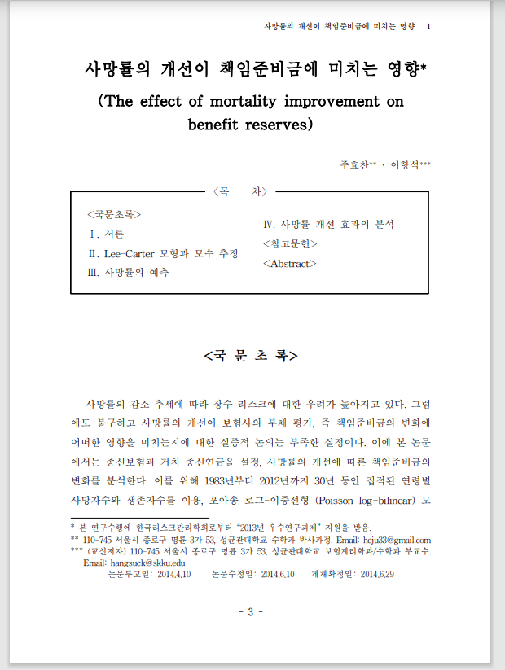

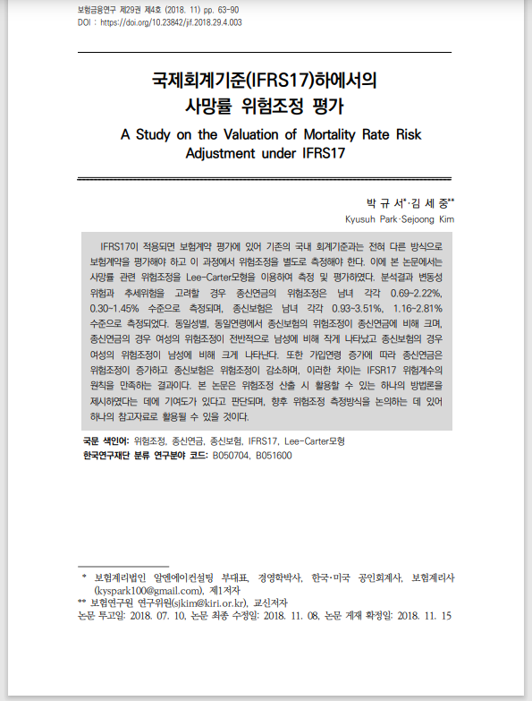

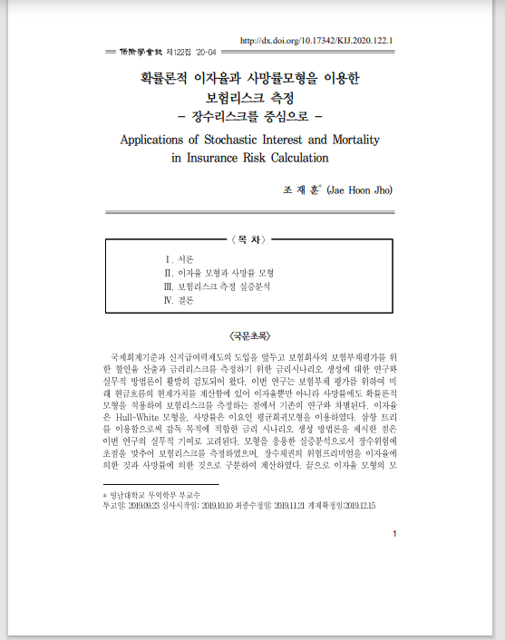

Figure 1: 3가지 논문